```python
import numpy as np
import pandas as pd
import matplotlib.pyplot as plt
from scipy import stats
import seaborn as sb
import sys
```

```python
df_ceo = pd.read_excel('ceo.xls.')
df_ceo.head()
```

|  | salary | totcomp | tenure | age | sales | profits | assets | Unnamed: 7 |
| --- | --- | --- | --- | --- | --- | --- | --- | --- |
| 0 | 3030 | 8138 | 7 | 61 | 161315.0 | 2956.0 | 257389.0 | NaN |
| 1 | 6050 | 14530 | 0 | 51 | 144416.0 | 22071.0 | 237545.0 | NaN |
| 2 | 3571 | 7433 | 11 | 63 | 139208.0 | 4430.0 | 49271.0 | NaN |
| 3 | 3300 | 13464 | 6 | 60 | 100697.0 | 6370.0 | 92630.0 | NaN |
| 4 | 10000 | 68285 | 18 | 63 | 100469.0 | 9296.0 | 355935.0 | NaN |

# Assignment 0

## Problem 1: Descriptive Statistics and Probability Theory: Real Data on CEO Compensation

1. a. For the variable totcomp compute the common location measures: mean, 5%- trimmed mean, median, upper and lower quartiles, the upper and lower 5%- quantiles. Give an economic interpretation for every location measure.

```python
mean = np.mean(df_ceo['totcomp'])
trim_mean = stats.trim_mean(df_ceo['totcomp'], 0.05)
median = np.median(df_ceo['totcomp'])
Q1 = np.percentile(df_ceo['totcomp'], 25, interpolation = 'midpoint')
Q3 = np.percentile(df_ceo['totcomp'], 75, interpolation = 'midpoint')
Q1_5 = np.quantile(df_ceo['totcomp'], 0.05, interpolation = 'midpoint')
Q3_5 = np.quantile(df_ceo['totcomp'], 0.95, interpolation = 'midpoint')

print (f"Mean = {mean}")
print(f"5-percent-trimmed mean = {trim_mean}")
print(f"Median = %G" % median)
print(f"Lower quartile = {Q1}, Upper Quartile = {Q3}")
print(f"Lower 5 percent Quantile = {Q1_5}")
print(f"Upper 5 percent Quantile = {Q3_5}")
```

```
Mean = 8340.058165548098
5-percent-trimmed mean = 4637.679900744417
Median = 2951
Lower quartile = 1575.5, Upper Quartile = 6043.0
Lower 5 percent Quantile = 787.5
Upper 5 percent Quantile = 24523.5
```

Economic interpretation for every location measure: Mean - depicts the average total compensation over the current set of values. 5% Trimmed mean - eliminates outliers in the data set. Median - median less depends on the outliers influence. It shows the total compensation of the average CEO. This indicator is more "social" in its nature.  
Mean, T-mean and Median values aren't approximately equal to each other, so the distribution in the sample is asymmetric. Lower quartile indicates the middle value for lower 50% of distribution. Upper quartile indicates the middle value for uper 50% of distribution equal. Lower 5% quantile indicates the value on the upper edge of the first 5% of dataset. Upper 5% quantile indicates the value on the lower edge of last 5% of dataset.

1. b. Plot the empirical cumulative distribution function. Compute and explain in economic terms the following quantities i. ^ F1(0:1) and ^ F1(0:9) ii. ^ F(2000) and 1  ^ F(4000)

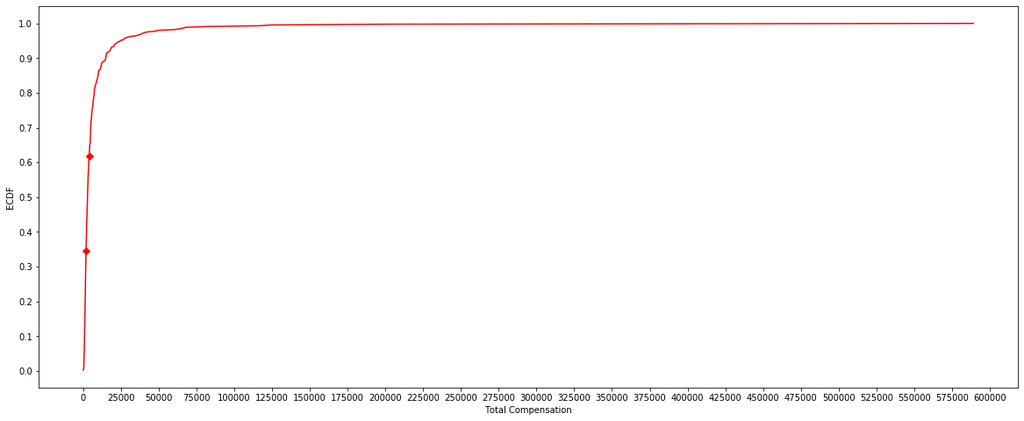

```
F^-1(0.1) =  1002.0
F^-1(0.9) =  15060.5
```

```python
data = df_ceo['totcomp']
x = np.sort(data)
y = np.arange(1, len(x)+1)/len(x)

plt.figure(figsize=(20,8))
plt.yticks(np.arange(0, 1.01, step=0.1))
plt.xticks(np.arange(0, 600001, step=25000))
markers_on = [154, 275]

plt.plot(x, y, '-rD', markevery=markers_on)
plt.xlabel('Total Compensation')
plt.ylabel('ECDF')
plt.show()
Q_10 = np.quantile(df_ceo['totcomp'], 0.1, interpolation = 'midpoint')
Q_90 = np.quantile(df_ceo['totcomp'], 0.90, interpolation = 'midpoint')
print("F^-1(0.1) = ", Q_10)
print("F^-1(0.9) = ", Q_90)
```

```
i.
We plotted the empirical cumulative distribution function and computed that if the relative frequency is 0.1 - the totalcomp is 1002, for 0.9 totcomp is 15060.5
ECDF function 𝐹−1(0.1) indicates maximum total Compensation for the first 10% of CEOs aranged by Total Compensation amount.     ECDF function 𝐹−1(0.9) indicates maximum total Compensation for the first 90% of CEOs aranged by Total Compensation amount.
ii.
ECDF function - $F(2000) - indicate hom many CEOs have Total Compensation less or equal to 2000 (around 35%), respectively     $F(4000) less or equal to 4000 (around 62%)
```

1.c. Plot the histogram of totcomp and the Box-plot (or violin-plot). What can be concluded about the distribution of the data? Are the location measures computed above still appropriate? Compute and discuss an appropriate measure of symmetry.

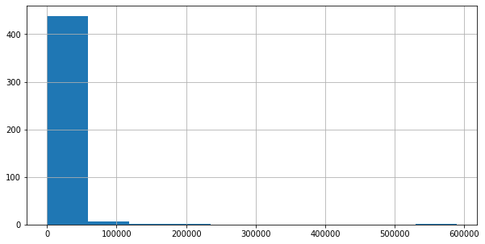

```python
plt.figure(figsize=(10,5))
df_ceo['totcomp'].hist(density=False)
plt.show()
```

We can see from the histogram that the vast majority of data (400 from 447) belongs to the single bean and the distribution is highly asymetric. There are outliers in data with relatively high Total Compensation.

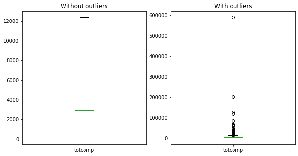

```python
plt.figure(figsize=(10,5))

plt.subplot(121)
df_totcomp = df_ceo[['totcomp']]
df_totcomp.boxplot(grid=False, showfliers=False)
plt.title('Without outliers')

plt.subplot(122)
df_totcomp = df_ceo[['totcomp']]
df_totcomp.boxplot(grid=False)
plt.title('With outliers')

plt.show()
```

Box plot depicts, that there are a few outliers in the right part of the distribution. A huge part of data belongs to the [0; 12500] interval and outliers has values up to almost 600000. Taking into account the histogram and boxPlot we can see, that the data distribution is asymmetric. That is why location values computed above are irrelevant.

1.d. Check which method is used in your software to compute the optimal bandwidth (or the number of bars) in the histogram. Describe it shortly here. Make plots of too detailed and too rough histograms. What can we learn from these figures?

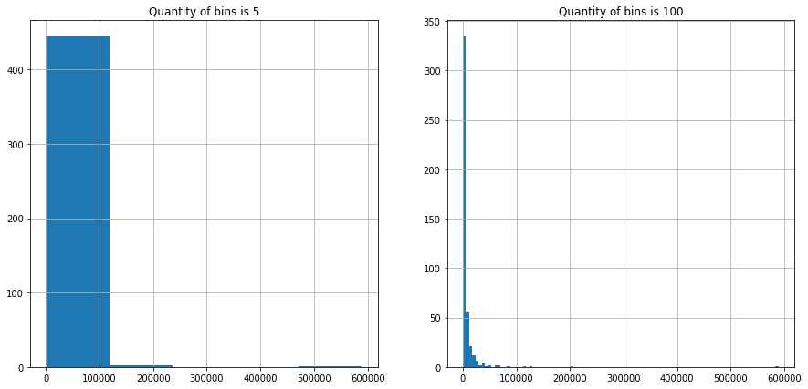

```python
plt.figure(figsize=(15,7))

plt.subplot(121)
df_ceo['totcomp'].hist(bins=5)
plt.title('Quantity of bins is 5')

plt.subplot(122)
df_ceo['totcomp'].hist(bins=100)
plt.title('Quantity of bins is 100')

plt.show()
```

Matplotlib.Histogram, has default number of bins equal to 10. Other methods which calculate number of bins could be divided into two categories:

a.Normal Reference rules have Scott and Freedman & Diaconis methods. Both assume that data is close to normal distribution and try to minimize difference between histogram and underlying distribution of data. Such rules provide good trade-off between accurate representation of data and noise reduction. Also they are not computational expensive. Downside of this methods is an assumption about data being normally distributed, hence such methods are not optimal for complex distributions.

b.Bayesin Models uses fitness fucntion on data to compute optimal bin size. Knuth method uses fixed bin size, while Bayesian Blocks method choose bins with different size. Since both methods requires minimization of cost function on the actual data, they are much more computation expensive compare with Normal Reference rules.

It is clear that both choices are suboptimal: with 5 bins, the fine structure of the data distribution is lost, while with 100 bins, heights of individual bins are affected by sampling error.

1. e. There are methods which help us make the distribution of the sample more sym- metric. Consider the natural logarithm of the total compensation: ln(totcomp). Plot the histogram (and Box-plot) and compare it with the figures for the original data. Compute the mean and the median. What can be concluded from the new values? Provide economic interpretation.

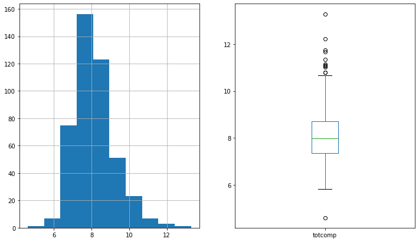

```
Original Mean = 8340.058165548098
Normalized Mean = 8.135686093478535
Original Median = 2951.0
Normalized Median = 7.989899374942939
```

```python
# Applying log function to Total Compensation to normalize the distribution
plt.figure(figsize=(12,7))

ln_hist = df_ceo['totcomp'].transform(np.log)
ln_bp = df_ceo[['totcomp']].transform(np.log)
plt.subplot(121)
ln_hist.hist()
plt.subplot(122)
ln_bp.boxplot(grid=False, showfliers=True)
plt.show()

mean= np.mean(df_ceo['totcomp'])
mean_ln = np.mean(ln_hist)
median = np.median(df_ceo['totcomp'])
median_ln = np.median(ln_hist)

print (f"Original Mean = {mean}")
print(f"Normalized Mean = {mean_ln}")
print(f"Original Median = {median}")
print(f"Normalized Median = {median_ln}")
```

From the histogram or boxplot we can see that the Total Compensation of majority of CEOs lies in the middle of the distribution with a slight shift to the left edge. This means there are fewer CEOs whose Total Compensation either too small or too large. Also, the number of CEOs who have high Total Compensation is bigger than the number of CEOs with relatively small Total Compensation.

### 2. Next we try to make a more detailed analysis of the data (without logarithm).

1. (a) We suspect that the total compensation of the CEO and other variables are related. Compute the correlation coeficients of Pearson and plot them as a heatmap (correlation map). Discuss the strength of the correlations.

Coefficient of Pearson is a parametric measure of correlation. It shows the strength of linear relation. less than 0.3 - weak correlation 0.3-0.5 moderate correlation 0.5-0.7 middle correlation 0.7-0.9 high correlation more then 0.9 - very high correlation So, moderate correlation is between salary and sales, profits, assets totcomp has moderate correlation with salary tenure has a moderate correlation with age sales has a high correlation with profits (0.73)

2.b. Plot the scatter plots (pairs in R). Conclude if the linear correlation coecients are appropriate here. Compute now the Spearman's correlations and make a heatmap. Compare the results with Pearson. What is the rank of the observation totcomp= 6000?

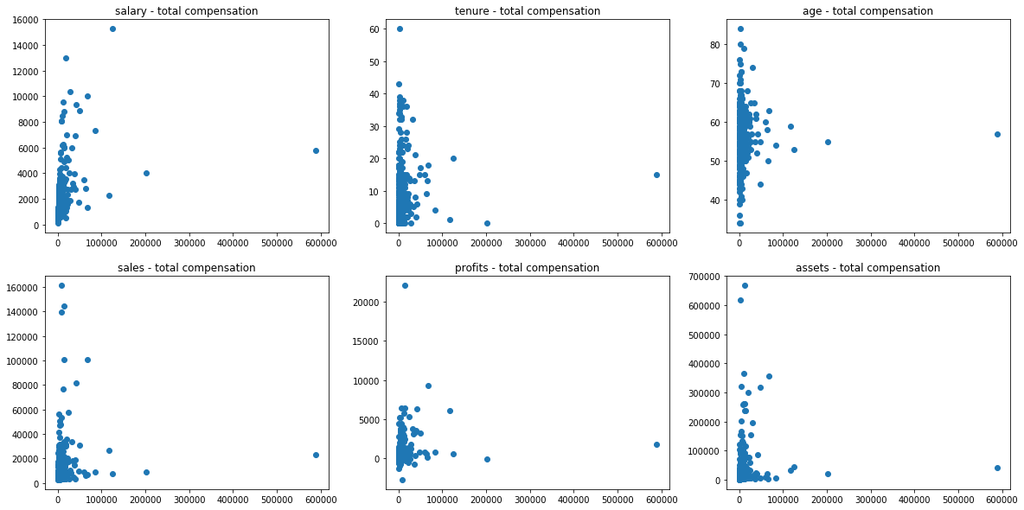

```python
plt.figure(figsize=(20,10))

num=231

for col in df_ceo.columns:
    if (col != 'Unnamed: 7') & (col != 'totcomp'):
        plt.subplot(num)
        plt.title(col+' - total compensation')
        plt.scatter(x=df_ceo['totcomp'], y=df_ceo[col])
        num=num+1

plt.show()
```

The linear correlation coefficients are not appropriate here because the distribution of the data in the sample is far from normal distribution. That is why it is reasonable to use the Spearman`s correlations for this sample.

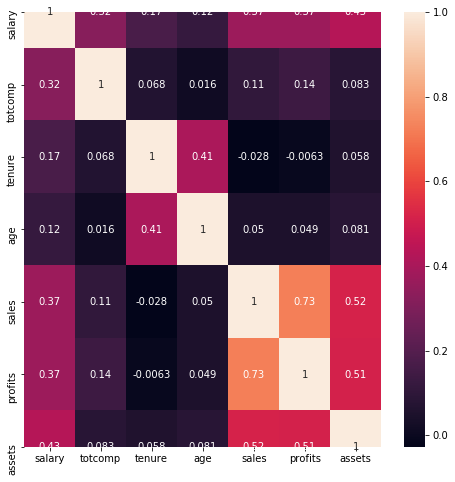

```python
cor_cofs = df_ceo.corr(method="pearson")
plt.figure(figsize=(8,8))
sb.heatmap(cor_cofs, annot=True)
plt.show()
```

```python
distance=sys.maxsize
rank=0
for idx, val in enumerate(np.sort(df_ceo['totcomp']), start=1):
    dist_tmp=abs(6000-val)
    if dist_tmp < distance:
        distance = dist_tmp
        rank=idx

print('Rank of totcomp=6000 is equal to: ', rank)
```

```
Rank of totcomp=6000 is equal to:  335
```

1. c. Consider the two subsamples: CEOs younger than 50 and older than 50. Plot for both subsamples overlapping histograms/ecdf's and discuss the results. What can we learn from the corresponding location and dispersion (!) measures?

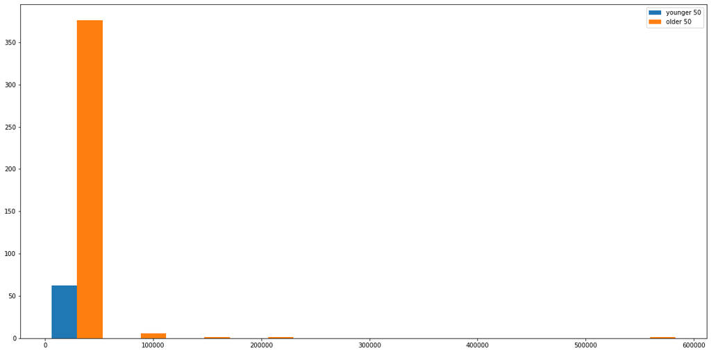

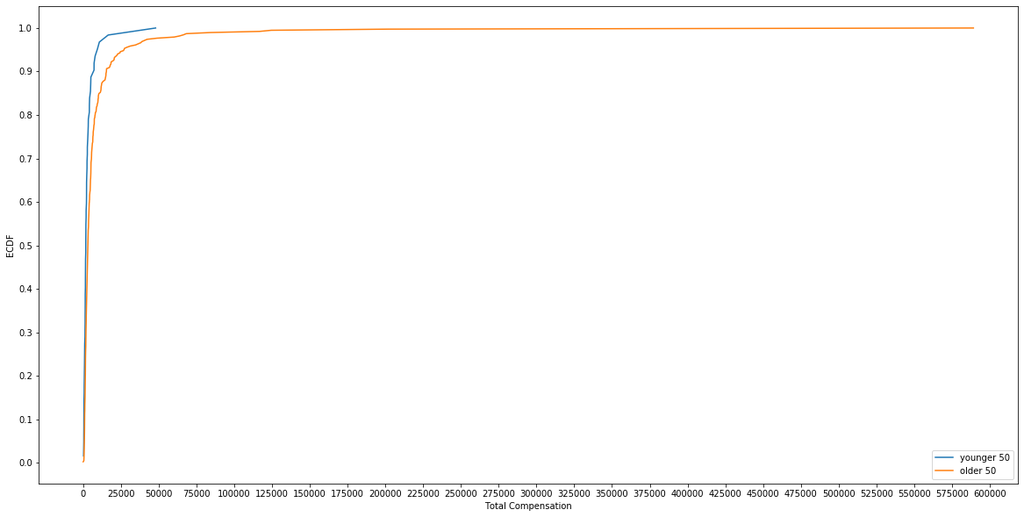

```python
data = df_ceo
data_lt50 = data[data['age'] < 50]
data_ge50 = data[data['age'] >= 50]

plt.figure(figsize=(20,10))

plt.hist([data_lt50['totcomp'], data_ge50['totcomp']], label=['younger 50', 'older 50'])
plt.legend(loc='upper right')
plt.show()

x1 = np.sort(data_lt50['totcomp'])
y1 = np.arange(1, len(x1)+1)/len(x1)

x2 = np.sort(data_ge50['totcomp'])
y2 = np.arange(1, len(x2)+1)/len(x2)

plt.figure(figsize=(20,10))
plt.yticks(np.arange(0, 1.01, step=0.1))
plt.xticks(np.arange(0, 600001, step=25000))

plt.plot(x1, y1, Label='younger 50')
plt.plot(x2, y2, Label='older 50')
plt.xlabel('Total Compensation')
plt.ylabel('ECDF')
plt.margins(0.05)
plt.legend(loc='lower right')
plt.show()
```

From the graphs above we can make conlusion, that the distribution for data under 50 years old is not spread so much as for CEOs data above 50 years old. Also,people who are over 50 gets higher salary than those who are younger than 50.

### 3. Consider another grouping of the data. Define the groups:

3 (a) Aggregate the data to a 2 x 3 contigency table with absolute and with relative frequencies.

Contigency table with absolute and relative frequencies:

```python
data = df_ceo

pd.crosstab([data['age'] < 50, data['age'] >= 50], [data['salary'] < 3000, (data['salary'] >= 3000) & (data['salary']<5000), data['salary'] >= 5000], rownames=['Age < 50', 'Age > 50'], colnames=['Salary < 3000', '3000< Salary <5000', 'Salary > 5000'], margins=True, margins_name='Total')
```

| Age < 50 | Salary < 3000 3000< Salary <5000 Salary > 5000 Age > 50 | False True | False True | True False | Total |
| --- | --- | --- | --- | --- | --- |
| False | True | 25 | 37 | 323 | 385 |
| True | False | 0 | 3 | 59 | 62 |
| Total |  | 25 | 40 | 382 | 447 |

```python
data = df_ceo
pd.crosstab([data['age'] < 50, data['age'] >= 50], [data['salary'] < 3000, (data['salary'] >= 3000) & (data['salary']<5000), data['salary'] >= 5000], rownames=['Age < 50', 'Age > 50'], colnames=['Salary < 3000', '3000< Salary <5000', 'Salary > 5000'], normalize=True)
```

| Age < 50 | Salary < 3000 3000< Salary <5000 Salary > 5000 Age > 50 | False True | False True | True False |
| --- | --- | --- | --- | --- |
| False | True | 0.055928 | 0.082774 | 0.722595 |
| True | False | 0.000000 | 0.006711 | 0.131991 |

1. (b) Give interpretation for the values of n12, h12, n1 and h1.

Value 𝑛12 means that there are 37 CEOs in the total with Age over 50 and Salary between 3000 and 5000. Value 𝑛1. means that there are in total 385 whose Age is over. Value ℎ12 shows that there are 8,27% of total number of CEOs whose Age is over 50 and Salary between 3000 and 5000. Value ℎ1. shows that there are 86.13% of total number of CEOs whose Age over 50 years old.

1. (c) Compute an appropriate dependence measure for Si and Aj . What can be concluded from its value?

```python
data = df_ceo
n = data.shape[0]
crosstab = pd.crosstab([data['age'] < 50, data['age'] >= 50], [data['salary'] < 3000, (data['salary'] >= 3000) & (data['salary']<5000), data['salary'] >= 5000], rownames=['Age < 50', 'Age > 50'], colnames=['Salary < 3000', '3000< Salary <5000', 'Salary > 5000'], margins=True, margins_name='Total')
f_obs = np.array([crosstab.iloc[0][0:3].values,
                  crosstab.iloc[1][0:3].values])
print(f'Dependency Measurement  = {stats.chi2_contingency(f_obs)[0]}')
```

```
Dependency Measurement  = 6.177696439264164
```

## Problem 2: Descriptive Statistics and Probability Theory: Simulated Data

1. (a) Plot the histogram and compare it to the density of N(10; 9).

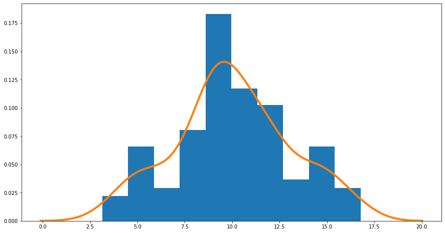

```python
np.random.seed(7)
mean, sigma = 10, 3
ds_norm = np.random.normal(mean, sigma, 100)
plt.figure(figsize=(15,8))
plt.hist(ds_norm, bins='auto', density=True)
sb.distplot(ds_norm, hist=False, kde=True, kde_kws={'linewidth': 4})
plt.show()
```

Histogram and the curve of density for the same distribution

1. (b) Now draw a sample yi of size n = 100 from t5. Transform it as follows: 10 + 3 p3=5  yi. Plot the histogram and compare the density of N(10; 9). What can be concluded and why this example might be relevant for empirical studies?

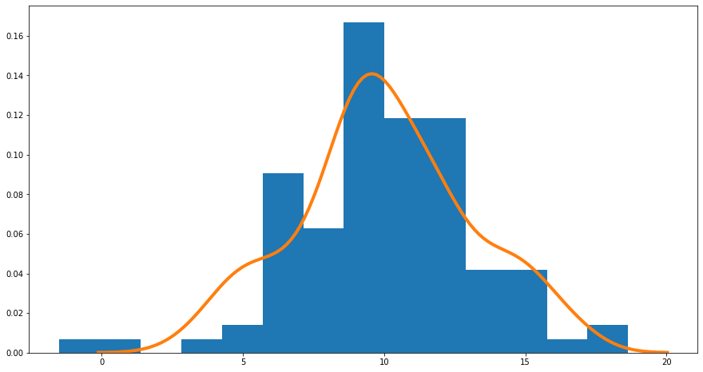

```python
np.random.seed(7)
ds_t5 = np.random.standard_t(5, 100)
ds_t5 = 10+3*np.sqrt(3/5)*ds_t5
plt.figure(figsize=(15,8))
plt.hist(ds_t5, bins='auto', density=True)
sb.distplot(ds_norm, hist=False, kde=True, kde_kws={'linewidth': 4})
plt.show()
```

The Students distribution on our plot does not follow the density function of N(10,3) on the left side of plot. Around the mean value we could assume that the Student behaves like Normal distribution, but on the edges there are bigger density of data that it should be in Normal distribution. Such distributions could be more usefull in empirical studies than Normal distribution, because Student has data on the edges of the distribution, which will serve as outliers.

1. (a) To obtain a realistic heterogenous sample add to the original normal data a new sample of size m simulated from N(20; 22), i.e. 2 = 20 and 2 2 = 4. The size m will obviously in uence the above measures. Vary m from 10 to 200. (The resulting sample is said to stem from a mixture normal distribution). (b) Plot Box-plots (or violin plots) and histograms for each subsample individually and for the sample for a few di erent values of m.

```
Histograms and Box Plots for subsamples of N(20, 2)
```

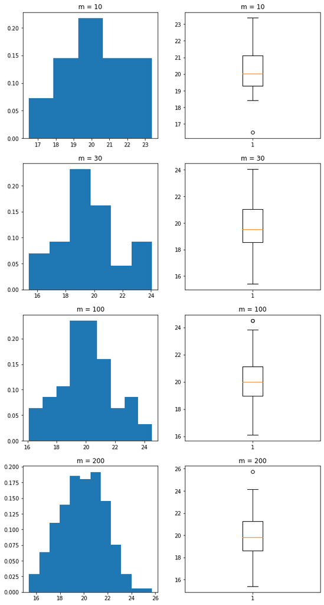

```python
np.random.seed(7)

mean, sigma = 20, 2

d={}
m_list = [10, 30, 100, 200]

for m in m_list:
    ds_norm_o = np.random.normal(mean, sigma, m)
    d['m'+str(m)] = (np.concatenate((ds_norm, ds_norm_o)), ds_norm_o)

print('Histograms and Box Plots for subsamples of N(20, 2)')
plt.figure(figsize=(10,20))
i=1
for item in d:
    _, ds_o = d[item]
    plt.subplot(4,2,i)
    i+=1
    plt.title('m = '+item[1:4])
    plt.hist(ds_o, bins='auto', density=True)
    plt.subplot(4,2,i)
    i+=1
    plt.title('m = '+item[1:4])
    plt.boxplot(ds_o)
```

As we could see from histograms and box plots for sub samples data is normally distributed with minimal to no number of outliers highlighted on the box plots.

Now we will blend data into original N(10,3) distribution and plot histogram and box plot after.

```
Histograms and Box Plots for samples mixed with subsamples of N(20, 2)
```

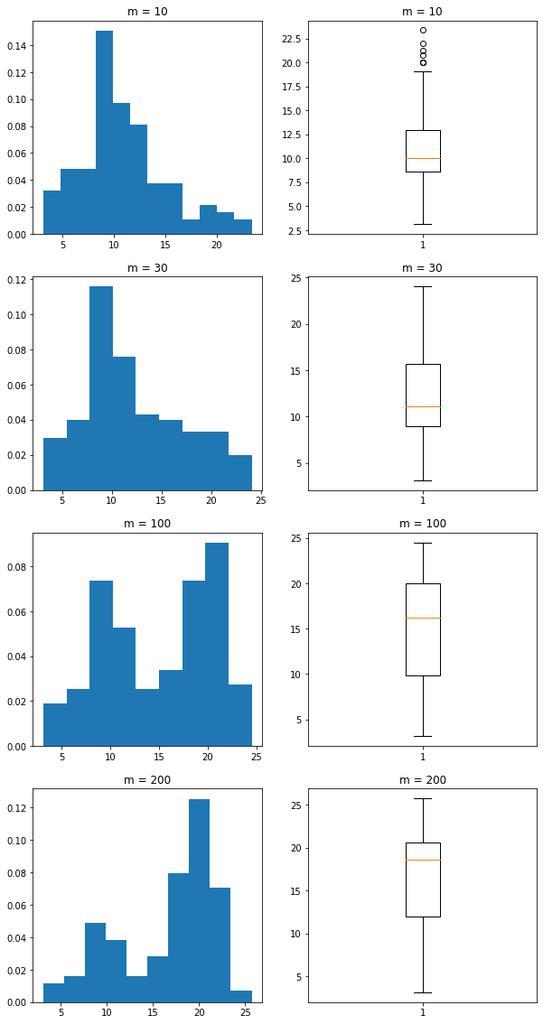

```python
print('Histograms and Box Plots for samples mixed with subsamples of N(20, 2)')
plt.figure(figsize=(10,20))
i=1
for item in d:
    ds_m,_ = d[item]
    plt.subplot(4,2,i)
    i+=1
    plt.title('m = '+item[1:4])
    plt.hist(ds_m, bins='auto', density=True)
    plt.subplot(4,2,i)
    i+=1
    plt.title('m = '+item[1:4])
    plt.boxplot(ds_m)
```

From the plots we can see, that subsamples of size 10 does not change distribution much. With subsample of size 30 distribution has slight shifted the data to the right, but distribution still looks close to the normal. With subsample of size 100 we could see two noticable peaks around Mean values for both distributions N(10,3) and N(20,2) which means that original distribution no longer normal one. And with subsample of size 200 there is a noticable shift of data to the Mean of 20 and there is another peak around Mean of 10. This also makes distribution not a Normal any longer.

1. (a) Let U  N(0; 1) and V  N(0; 1). Let U = U and V  = U + p 1  2V . Prove that Corr(U; V ) =  and the variances of both variables U and V  equal one.

```python
np.random.seed(7)
mean, sigma = 0, 1

p = 0.77

ds_U = np.random.normal(mean, sigma, 100)
ds_V = np.random.normal(mean, sigma, 100)
ds_Vt = p*ds_U + np.sqrt(1-p**2)*ds_V

print(f'Corr(U,V) = {stats.pearsonr(ds_U, ds_Vt)[0]}')
print(f'Variance of U = {np.var(ds_U)}')
print(f'Variance of V = {np.var(ds_Vt)}')
```

```
Corr(U,V) = 0.768864010726626
Variance of U = 1.0378302627823814
Variance of V = 0.910599784387689
```

We can see that Corr(U,V) is almost the same as the original p value choosen initially. However Variances for U and V slightly deviates ~10%.